# **United States Covid19 Anaylsis**

By Lucas Croy

Due to the political nature of the Covid 19 pandemic it has been incredibly frustrating to not know the true nature of the virus. I was interested in learning the real danger of Covid and who it has affected and harmed the most.

# **Packages**

```python
import pandas as pd
import numpy as np
from google.colab import files
import matplotlib.pyplot as plt
import sklearn
from sklearn.model_selection import train_test_split
from sklearn.preprocessing import StandardScaler
from sklearn.neural_network import MLPClassifier
from sklearn.metrics import classification_report,confusion_matrix
```

```python
# uploaded = files.upload()

# from google.colab import drive
# drive.mount('/content/drive')

df = pd.read_csv("/content/drive/MyDrive/COVID-19_Case_Surveillance_Public_Use_Data_with_Geography.csv")
```

```python
df.head()
```

|  | case_month | res_state | state_fips_code | res_county | county_fips_code | age_group | sex | race | ethnicity | case_positive_specimen_interval | case_onset_interval | process | exposure_yn | current_status | symptom_status | hosp_yn | icu_yn | death_yn | underlying_conditions_yn |
| --- | --- | --- | --- | --- | --- | --- | --- | --- | --- | --- | --- | --- | --- | --- | --- | --- | --- | --- | --- |
| 0 | 2020-02 | NaN | NaN | NaN | NaN | NaN | NaN | NaN | NaN | 6.0 | 0.0 | Missing | Missing | Laboratory-confirmed case | Symptomatic | No | Missing | No | Yes |
| 1 | 2020-02 | NaN | NaN | NaN | NaN | NaN | NaN | NaN | NaN | NaN | 0.0 | Missing | Missing | Laboratory-confirmed case | Symptomatic | No | Missing | No | NaN |
| 2 | 2020-02 | NaN | NaN | NaN | NaN | NaN | NaN | NaN | NaN | 3.0 | 0.0 | Missing | Missing | Laboratory-confirmed case | Symptomatic | No | Missing | No | Yes |
| 3 | 2020-02 | NaN | NaN | NaN | NaN | NaN | NaN | NaN | NaN | 3.0 | 0.0 | Clinical evaluation | Unknown | Laboratory-confirmed case | Symptomatic | No | No | No | NaN |
| 4 | 2020-02 | NaN | NaN | NaN | NaN | NaN | NaN | NaN | NaN | 12.0 | 0.0 | Other | Yes | Laboratory-confirmed case | Symptomatic | No | No | No | Yes |

```python
df.drop("state_fips_code", inplace=True, axis=1)
df.drop("res_county", inplace=True, axis=1)
df.drop("county_fips_code", inplace=True, axis=1)
df.drop("case_positive_specimen_interval", inplace=True, axis=1)
df.drop("current_status", inplace=True, axis=1)
```

This dataset comes from the CDC and can be found at https://data.cdc.gov/Case-Surveillance/COVID-19-Case-Surveillance-Public-Use-Data-with-Ge/n8mc-b4w4. Due to the large filesize (3.5 gb) I uploaded the dataset to google drive and mounted it in the colab repository. I dropped state_fips_code, res_county, county_fips_code, case_positive_specimen_interval, and current_status. The FIPS codes and res_county were dropped because I will not use FIPS and I will be looking at State only not county. case_positive_specimen_interval and current_status were dropped because I will not be using those values in my analysis.

# **Missing Data**

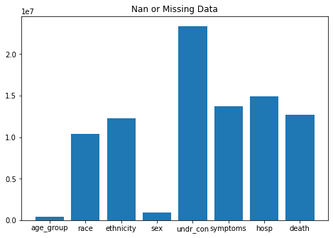

```python
def check_missing(inp):
  i = 0
  values = df[inp].value_counts()
  if values.get('Unknown') is not None:
    i += values['Unknown']
  if values.get('Missing') is not None:
    i += values['Missing']
  return i

#age/race/ethnicity/sex/underlying conditions/symptom_status/hosp_yn/death_yn
age = df['age_group'].isnull().sum() + check_missing('age_group')
race = df['race'].isnull().sum() + check_missing('race')
ethnicity = df['ethnicity'].isnull().sum() + check_missing('ethnicity')
sex = df['sex'].isnull().sum() + check_missing('sex')
underlying_conditions = df['underlying_conditions_yn'].isnull().sum() + check_missing('underlying_conditions_yn')
symptom_status = df['symptom_status'].isnull().sum() + check_missing('symptom_status')
hosp_yn = df['hosp_yn'].isnull().sum() + check_missing('hosp_yn')
death_yn = df['death_yn'].isnull().sum() + check_missing('death_yn')

fig = plt.figure()
ax = fig.add_axes([0,0,1,1])
ax.bar(["age_group", "race", "ethnicity", "sex", "undr_con", "symptoms", "hosp", "death"],
       [age, race, ethnicity, sex, underlying_conditions, symptom_status, hosp_yn, death_yn])
plt.title("Nan or Missing Data")
plt.show()
```

Some small amounts of data could be explained as Nan due to the CDC "prevent release of data that could be used to identify people, data cells are suppressed for low frequency." However, the other missing, unknown, or Nan values are more difficult to explain.

# **Data Visualization and Anylsis**

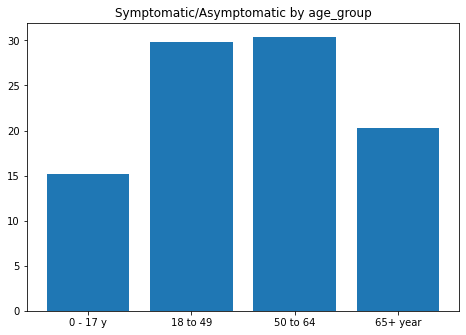

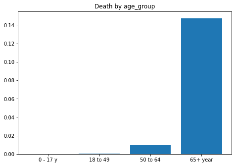

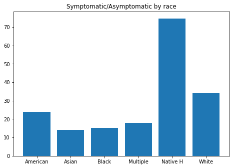

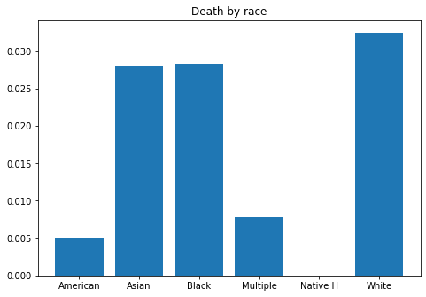

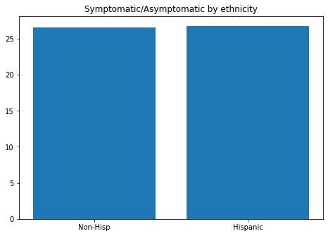

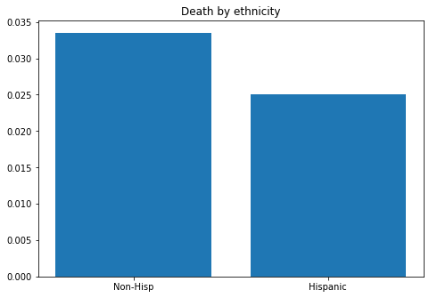

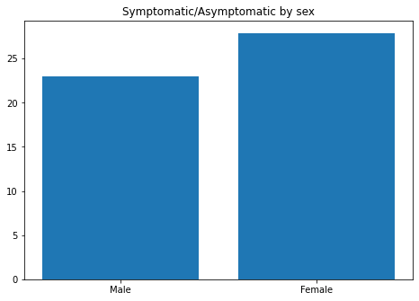

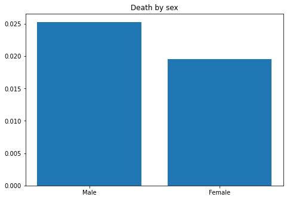

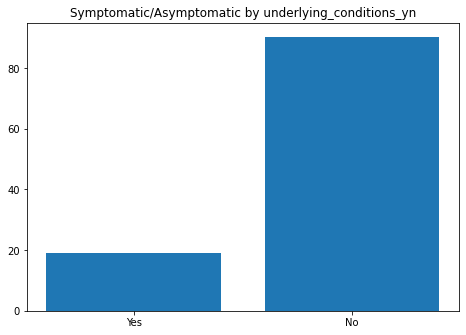

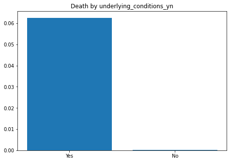

```python
#age and symptomatic/hospilized/death

def check_yes(value):
  if value.get('Yes') is None:
    return 0
  else:
    return value.get('Yes')

def grapher(inputs, title):
  counts_sym = []
  counts_dth = []
  for item in inputs:
    counts_sym.append((df[df[title] == item]['symptom_status']).value_counts())
    counts_dth.append((df[df[title] == item]['death_yn']).value_counts())
  fig = plt.figure()
  ax = fig.add_axes([0,0,1,1])

  inputs = [i[0:8] for i in inputs]
  ax.bar(inputs, [i['Symptomatic']/i['Asymptomatic'] for i in counts_sym])
  plt.title("Symptomatic/Asymptomatic by " + title)
  plt.show()

  fig = plt.figure()
  ax = fig.add_axes([0,0,1,1])
  ax.bar(inputs, [check_yes(i)/(i['No'] + check_yes(i)) for i in counts_dth])
  plt.title("Death by " + title)
  plt.show()


grapher(["0 - 17 years", "18 to 49 years", "50 to 64 years", "65+ years"], "age_group")
grapher(['American Indian/Alaska Native', 'Asian', 'Black', 'Multiple/Other', 'Native Hawaiian/Other Pacific Islander', 'White'], "race")
grapher(['Non-Hispanic/Latino', 'Hispanic/Latino'], "ethnicity")
grapher(['Male', 'Female'], 'sex')
grapher(['Yes', 'No'], 'underlying_conditions_yn')
```

```python
# print(df.race.count_values())
print((df['underlying_conditions_yn']).value_counts())
```

```
Yes    1603279
No       20498
Name: underlying_conditions_yn, dtype: int64
```

# **Machine Learning**

```python
ml_data = df[(df.age_group.notnull()) & (df.age_group != "Missing") &
             (df.race != "Missing") & (df.race != "Unknown") & (df.race.notnull()) &
             (df.ethnicity != "Missing") & (df.ethnicity != "Unknown") & (df.ethnicity.notnull()) &
             (df.underlying_conditions_yn != "Missing") & (df.underlying_conditions_yn != "Unknown") & (df.underlying_conditions_yn.notnull()) &
             (df.death_yn != "Missing") & (df.death_yn != "Unknown") & (df.death_yn.notnull()) &
             (df.sex != "Missing") & (df.sex != "Unknown") & (df.sex.notnull())]


ml_data = pd.concat([ml_data['age_group'], ml_data['race'], ml_data['ethnicity'], ml_data['underlying_conditions_yn'],
                     ml_data['sex'], ml_data['death_yn']], axis=1, keys=['age_group', 'race', 'ethnicity', 'underlying_conditions_yn', 'sex', 'death_yn'])

ml_data.replace(to_replace="0 - 17 years", value=0, inplace=True)
ml_data.replace(to_replace="18 to 49 years", value=1, inplace=True)
ml_data.replace(to_replace="50 to 64 years", value=2, inplace=True)
ml_data.replace(to_replace="65+ years", value=3, inplace=True)

ml_data.replace(to_replace='Yes', value=1, inplace=True)
ml_data.replace(to_replace='No', value=0, inplace=True)

ml_data.replace(to_replace='Male', value=0, inplace=True)
ml_data.replace(to_replace='Female', value=1, inplace=True)

ml_data.replace(to_replace='American Indian/Alaska Native', value=0, inplace=True)
ml_data.replace(to_replace='Asian', value=1, inplace=True)
ml_data.replace(to_replace='Black', value=2, inplace=True)
ml_data.replace(to_replace='Multiple/Other', value=3, inplace=True)
ml_data.replace(to_replace='Native Hawaiian/Other Pacific Islander', value=4, inplace=True)
ml_data.replace(to_replace='White', value=5, inplace=True)

ml_data.replace(to_replace='Non-Hispanic/Latino', value=0, inplace=True)
ml_data.replace(to_replace='Hispanic/Latino', value=1, inplace=True)
```

```python
x = ml_data.drop('death_yn', axis=1)
y = ml_data['death_yn']

x_train, x_test, y_train, y_test = train_test_split(x, y)

model = MLPClassifier(hidden_layer_sizes=(5,5, 5, 5), max_iter=1000, early_stopping=True)
model.fit(x_train, y_train)
predict = model.predict(x_test)

print(classification_report(y_test,predict))
```

```
              precision    recall  f1-score   support

           0       0.93      1.00      0.96    168342
           1       0.72      0.03      0.05     13109

    accuracy                           0.93    181451
   macro avg       0.82      0.51      0.51    181451
weighted avg       0.91      0.93      0.90    181451
```

# **Conclusions**

The results of the data analysis show a few different results. The 0-18 age group has the highest amount of asymptomatic cases versus symptomatic cases. The 65+ age group had the highest death rate by far. The American Indian/Alaska Native and Multiple/Other races had the lowest rates of death. The Native Hawaiian/Other Pacific Islander had zero deaths which seems to be an error considering the average for other races. The only difference between hispanic and non-hispanic was the death rate which was a considerable difference. Women were more likely to be symptomatic than men however men were more likely to die from Covid. By far the biggest correlation between a variable and likelyhood of death was underlying conditions. The ratio of symptomatic to asymptomatic was suprisingly low for those with underlying conditions.